# Proyecto práctico de evaluación

Tratamiento de Datos. Grado en Ciencia de Datos - UV

Carlos Santiago Martinez Torres

2025-04-26

# 1 Instalacion automática de paquetes

## 1.1 Enunciado

1. Crea un proyecto llamado NosAnalizamos con un fichero Rmarkdown denominado NosAnalizamos.Rmd y al menos una carpeta (data) que contenga el fichero de datos.

## 1.2 Enunciado

2. Asegúrate que se instalan las librerías necesarias en caso de que no estén instaladas en el ordenador en el que se ejecuta el proyecto.

```r
# Asegurarse de que el paquete "pacman" está instalado
if (!require("pacman")) install.packages("pacman")
```

Una vez que el paquete pacman está instalado/cargado, establecemos las librerias que vamos a usar.

```r
pacman::p_load(tidyverse, readxl, lubridate, knitr, visdat, GGally, PerformanceAnalytics)

# Con tidyverse: ggplot2, dplyr, tidyr, readr, purrr, tibble, stringr, forcats
# readxl, libreria que requiere una carga aparte explícita
# lubridate, se utiliza con frecuencia con paquetes de tidyverse, pero requiere una carga aparte
# visdat, exploracion visual de los datos. Especialmente para datos faltantes
# GGally, graficar correlaciones de variables
# PerformanceAnalytics, Crear gráfico de correlacion en R con histogramas, funciones de densidad, lineas de regresión, y coeficientes de relación
```

# 2 Carga de datos

## 2.1 Enunciado

3. Carga el fichero de datos en R y llama datos al data frame obtenido. Este data frame contendrá exclusivamente las columnas con variables y las filas que contengan datos. Se sabe que los datos empiezan en la fila 25 pero NO cuántos alumnos puede haber por lo que la determinación selección de filas con datos debe ser AUTOMÁTICA.

```r
# nombre_fichero <- 'NosAutoanalizamos2022 - Hoja1.tsv'
nombre_fichero <- 'NosAutoanalizamos2025 - Hoja1.tsv'
fichero <- file.path('./data', nombre_fichero)

datos <- read.delim(file=fichero, header=FALSE, sep='\t')
```

# 3 Limpieza de datos

Una vez que ya cargamos el fichero, vamos a quedarnos solo con los valores que nos interesan.

```r
# Informacion sobre los datos almacenados, fijo
InfoCode <- datos[1:19, ]

# Sabemos que los datos empiezan a partir de la linea 25
# Filtramos desde las primeras 25 lineas
datos <- datos[25:nrow(datos), ]
```

Buscamos el registro que contiene ‘FechaNac’, ya que a partir de ahí, tomaremos los datos a trabajar.

```r
# Al conjunto datos, por cada fila(1) -2 para columna-, evaluo si cualquier valor es 'FechaNac'
f1 <- which(apply(X = datos, MARGIN = 1, FUN = function(fila) any(grepl('FechaNac', fila))))[[1]]
f2 <- which(apply(X = datos, MARGIN = 2, FUN = function(col) any(grepl('FechaNac', col)))) # Para la col que contiene FechaNac
col_FechaNac <- names(datos)[f2]

# Filtrar desde f1 hasta el final, con todas las filas
datos <- datos[f1:nrow(datos), f2:ncol(datos)]
```

Ahora tomamos las columnas que contienen las variables de interes.

```r
# Seleccionamos las variables de interes en la informacion de las variables
f3 <- which(apply(X = InfoCode, MARGIN = 2, FUN = function(col) any(grepl('Fecha', col))))
col_info <- names(InfoCode)[f3]

InfoCode <- InfoCode %>%
              select(all_of(col_info))

colnames(InfoCode) <- c('Variable', 'Descripcion')
```

Dado que los pares del conjunto, fecha y id no se debería repetir, eliminamos aquellos datos que estan parcialmente duplicados. Esto ayuda a eliminar los registros vacios.

```r
# # No empleamos estas funciones, ya que no hay valores NA, y de haberlo un regitro con al menos un NA, eliminaria informacion relevante

# # Eliminar filas que tengan todos los valores vacíos (NA)
# datos[!apply(is.na(datos), 1, all), ]
#
# # Eliminar filas que tengan algún valor vacío (NA)
# datos[complete.cases(datos), ]

f4 <- which(apply(X = datos, MARGIN = 2, FUN = function(fila) any(grepl('Id', fila)))) # Para la col que contiene Id
col_Id <- names(datos)[f4]

datos <- datos %>%
            distinct(across(all_of(c(col_FechaNac, col_Id))), .keep_all = TRUE)
```

Si comprobamos el df, vemos que aún hay registros que no son relevantes para nuestro analisis.

```r
# La primer fila del df debe ser el nombre de las columnas
head(datos, 3)

# Hay un registro con todos los campos vacios
tail(datos, 3)
```

Extraemos el nombre de las columnas, que están en el primer registro del df, para asignarlos correctamente.

```r
# Obtenemos el vector de los nombres de las columnas
nombres <- as.character(datos[1, ])

# Del df de datos, elimamos el registro que contiene los nombres
datos <- datos[-1, ]
```

```r
kable(InfoCode,
      caption= 'Informacion de los datos almacenados',
      booktabs= TRUE)
```

Table 3.1: Informacion de los datos almacenados

| Variable | Descripcion |
| --- | --- |
| Fecha | Fecha de nacimiento en formato 29-01-2001 |
| Identificación | Usuario de correo UV. martsobm |
| Age | Edad en años. |
| Sex | Sexo de nacimiento: F/M |
| Wr.Hnd | Distancia del extremo del meñique al extremo del pulgar de la mano con la que escribimos. (en centímetros) PALMO |
| NW.Hnd | Mano con la que escribes: Izquierda, Derecha |
| Fold | Cruza los brazos. Qué brazo está arriba ?: Izquierdo, Derecho |
| Pulse | Cuál es tu ritmo cardíaco, en reposo, en latidos por minuto. |
| Clap | Aplaude. ¿Cómo están las manos ?. 3 casos. ‘Der s Izd’, (Derecha sobre izquierda) ’ Izq s Der’, ‘Ninguna’ |
| Smoke | Fumas: Si / No |
| Exer | Cuántos días a la semana realizas ejercicio físico. Numérica 0-7 |
| Height | Altura (en centímetros) |
| ALG | Calificación numérica obtenida en álgebra. Usa NA para no presentado y NC, para no compensable, si procede, o la nota numérica con un decimal (7,8) |
| ANM | Calificación numérica obtenida en análisis matemático. Usa NA para no presentado y NC, para no compensable, si procede, o la nota numérica con un decimal (7,8) |
| FP | Calificación numérica obtenida en fundamentos de programación. Usa NA para no presentado y NC, para no compensable, si procede, o la nota numérica con un decimal (7,8) |
| DCS | Calificación numérica obtenida en Datos Ciencia y Sociedad. Usa NA para no presentado y NC, para no compensable, si procede, o la nota numérica con un decimal (7,8) |
| MD | Calificación numérica obtenida en Matemática Discreta. Usa NA para no presentado y NC, para no compensable, si procede, o la nota numérica con un decimal (7,8) |
| HSt | Horas de trabajo DIARIAS relacionadas con los estudios, además de la asistencia a clase. |
| Hwork | ¿Tienes un trabajo remunerado además del estudio ?. Indica las horas de trabajo SEMANALES. 0 indica que no tiene otro trabajo. |

Siguiendo el formato del CodeBook que se observa en la Tabla 3.1, es como vamos a actualizar los nombres del df.

```r
# Actualizamos los nombres necesarios de acuerdo al CodeBook
nombres[1] <- 'Fecha'

# Actualizamos los nombres en el df
colnames(datos) <- nombres
```

Antes de continuar, quitaremos los registros vacios. Para ello, sabiendo que tanto la fecha como el id son valores no vacios, filtramos por aquellos que si lo son.

```r
datos <- datos %>%
  filter(!Fecha== '' | !Id== '')
```

Podemos comprobar los datos almacenamos en el df datos, que se muestran en la tabla 3.2.

Table 3.2: Registros almacenados

| Fecha | Id | Age | Sex | Wr.Hnd | NW.Hnd | Fold | Pulse | Clap | Exer | Smoke | Height | ALG | ANM | FP | DCS | MD | HSt | Hwork | Comentarios |
| --- | --- | --- | --- | --- | --- | --- | --- | --- | --- | --- | --- | --- | --- | --- | --- | --- | --- | --- | --- |
| 20-01-1969 | martsobm | 55 | M | 22 | Derecha | Izquierdo | 65 | Der s Izq | 2 | No | 178 | NP | 7 | 6 | 4 | 3,8 | 5 | 37,5 | Seguro que este grupo es el mejor que he tenido hasta ahora. Los datos son la electricidad del siglo XXI. En TD aprenderemos a manejarlos y extraer información de los mismos. |
| 22-02-2006 | olrae | 18 | Masculino | 20 | dercha | izquierdo | 60 | Der s Izq | 12 | No | 173 | 7,2 | 6,2 | NP | 4 | 1,7 | 1,5 | 5 | Esta asignatura es la mejor de todas me encanta el almacenamiento de los datos y como se comportan |
| 07-11-2006 | jusieal | 18 | M | 20 | Derecha | Izquierdo | 62 | Der s Izq | 1 | De fiesta | 180 | 6 | 7 | 3,91 | 7,6 | 5,3 | 1 | 0 | Asignatura práctica y amena |
| 28-01-2004 | jovimo3 | 21 | Masculino | 18 | Derecha | Izquierdo | 65 | Der s Izq | 3 | No | 173 | 6,2 | 6,6 | 9 | 8,3 | 5 | 3 | 0 | Esta asignatura es mejor que la de bases de datos |
| 11-10-2003 | carmart4 | 21 | M | 20 | Derecha | Izquierdo | 69 | Der s Izq | 3 | No | 172 | 8,5 | 8,2 | 9 | 9 | 8 | 6 | 25 | El control de versiones es fundamental para los trabajos de entrenamiento de modelos de aprendizaje |

Verificamos el tipo de dato que tenemos en cada una de las variables de nuestro dataframe.

```r
glimpse(datos)
```

```
## Rows: 59
## Columns: 20
## $ Fecha       <chr> "20-01-1969", "22-02-2006", "07-11-2006", "28-01-2004", "1…
## $ Id          <chr> "martsobm", "olrae", "jusieal", "jovimo3", "carmart4", "an…
## $ Age         <chr> "55", "18", "18", "21", "21", "18", "19", "18", "18", "18"…
## $ Sex         <chr> "M", "Masculino", "M", "Masculino", "M", "M", "M", "M", "F…
## $ Wr.Hnd      <chr> "22", "20", "20", "18", "20", "21", "16", "17", "9,5", "16…
## $ NW.Hnd      <chr> "Derecha", "dercha", "Derecha", "Derecha", "Derecha ", "De…
## $ Fold        <chr> "Izquierdo", "izquierdo", "Izquierdo", "Izquierdo", "Izqui…
## $ Pulse       <chr> "65", "60", "62", "65", "69", "65", "92", "62", "65", "70"…
## $ Clap        <chr> "Der s Izq", "Der s Izq", "Der s Izq", "Der s Izq", "Der s…
## $ Exer        <chr> "2", "12", "1", "3", "3", "8", "si", "", "3", "2", "4", "2…
## $ Smoke       <chr> "No", "No", "De fiesta", "No", "No", "Si", "no", "No", "No…
## $ Height      <chr> "178", "173", "180", "173", "172", "179", "185", "170", "1…
## $ ALG         <chr> "NP", "7,2", "6", "6,2", "8,5", "3,3", "6,8", "3,5", "NC",…
## $ ANM         <chr> "7", "6,2", "7", "6,6", "8,2", "6,3", "7,8", "3,7", "7,2",…
## $ FP          <chr> "6", "NP", "3,91", "9", "9", "0,65", "2,75", "1,8", "3", "…
## $ DCS         <chr> "4", "4", "7,6", "8,3", "9", "6,4", NA, "4", "7,9", "8,6",…
## $ MD          <chr> "3,8", "1,7", "5,3", "5", "8", "5", "6,3", "2,5", "6,2", "…
## $ HSt         <chr> "5", "1,5", "1", "3", "6", "2", "0", "0,5", "2", "4", "", …
## $ Hwork       <chr> "37,5", "5", "0", "0", "25", "12", "0", "0", "0", "2", "",…
## $ Comentarios <chr> "Seguro que este grupo es el mejor que he tenido hasta aho…
```

En la siguiente figura 3.1 se identifican los valores NA. Habrá que hacer la conversión al tipo correcto de dato para ver que inconsistencias podemos tener.

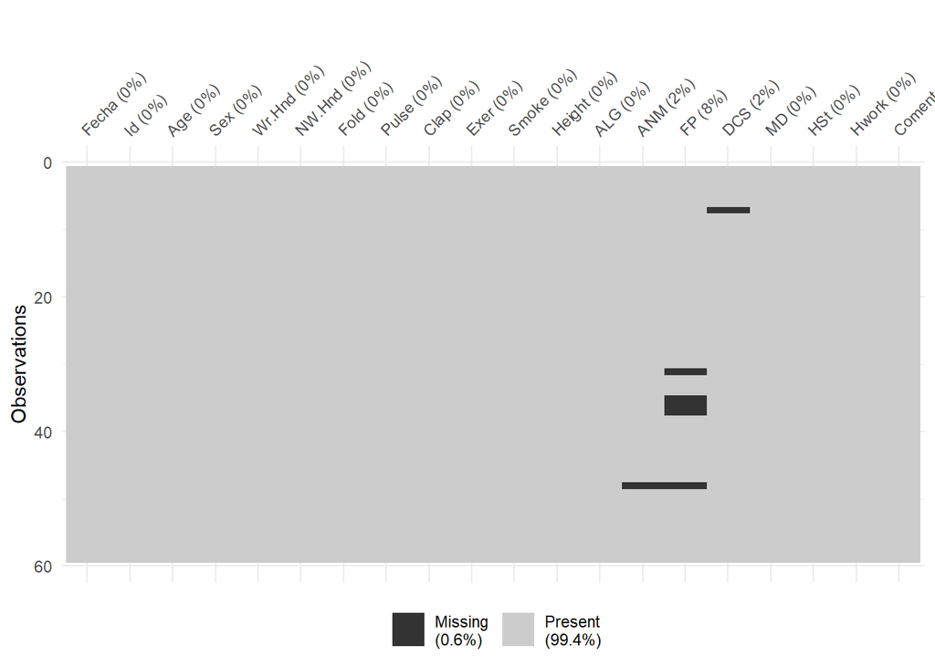

Figure 3.1: Visualizacion de datos NA

```r
vis_miss(datos)
```

## 3.1 Tratamiento de datos

## 3.2 Enunciado

4. Elimina al usuario cuyo id es martsobm del conjunto de datos.

```r
datos <- datos %>%
  filter(!Id =='martsobm')
```

## 3.3 Enunciado

5. Selecciona las columnas con las calificaciones y adecúalas para que al transformar a tipo numérico los valores sean correctos (recuerda que el separador decimal es el punto). Si alguna calificación es NC se sustituirá por 3. Cualquier otro valor no conocido se sustituirá por NA (por ejemplo “6 y pico”, no es un valor conocido).

Seleccionamos las columnas de las calificaciones

```r
inicio_cal <- which(colnames(datos) == 'ALG')
final_cal <- which(colnames(datos) == 'MD')
```

```r
# across: permite aplicar una misma operacion a varias columnas de un mutate() o summarise()
# .cols: seleccion de columnas
# everything(), starts_with(), ends_with(), matches(), contains(), c(col1, col2), col1:col5
# .fns: funcion o lista de funciones a aplicar a cada columna seleccionada.
# .names: El nombre de las nuevas columnas. Por defecto, FALSE.

# Vemos que no hay valores o expresiones como '6 y pico'. Por lo tanto podremos aplicar as.numeric al dataframe.

# Si solo se está filtrando, no es necesario hacer un select.

datos %>%
  filter(if_any(.cols = inicio_cal:final_cal,
                .fns = ~ str_length(.) >= 4))
```

Aplicamos, para cada columna, la condicion, haciendo el respectivo cambio de tipo de dato.

```r
datos[inicio_cal:final_cal] <- datos %>%
                                select(inicio_cal:final_cal) %>%

                                # Reemplazamos para que el separador decimal sea el punto
                                mutate(across( .cols = everything(),
                                               .fns = ~ str_replace_all(., ',', '.'))) %>%

                                # Personalizamos la funcion, para pasar una lista a ifelse
                                mutate(across( .cols = everything(),
                                               .fns = ~ifelse(.=='NC', 3, round(as.numeric(.), 1)))) # Un decimal
```

## 3.4 Enunciado

6. Obtén una tabla de estadísticos de estas variables. Donde en la primera columnas aparezca cada una de las asignaturas y las siguientes columnas se correspondan con los estadísticos que se indican, en este orden: valor mínimo, percentil25, mediana, valor medio, desviació típica, percentil75, valor máximo. Los resultados se mostrarán con 2 decimales.

Vease tabla 3.3.

```r
df_notas <- datos[inicio_cal:final_cal]
df_estadisticos_notas <- df_notas %>%
  pivot_longer(cols = ALG:MD,
               names_to = 'Asignatura',
               values_to = 'Nota') %>%
  group_by(Asignatura) %>%
  summarise(across(.cols = everything(),
                    .fns = list(minimo = ~ min(., na.rm = TRUE),
                                percentil25 = ~ quantile(., probs = 0.25, na.rm = TRUE),
                                mediana = ~ median(., na.rm = TRUE),
                                medio = ~ mean(., na.rm = TRUE),
                                desviaciontipica = ~ sd(., na.rm = TRUE),
                                percentil75 = ~ quantile(., probs = 0.75, na.rm = TRUE),
                                maximo = ~ max(., na.rm = TRUE)))) %>%
  mutate(across(.cols = starts_with('Nota'),
         .fns = ~ round(., digits = 2)))

kable(df_estadisticos_notas,
      caption = 'Tabla de estadisticos sobre notas',
      booktabs = FALSE)
```

Table 3.3: Tabla de estadisticos sobre notas

| Asignatura | Nota_minimo | Nota_percentil25 | Nota_mediana | Nota_medio | Nota_desviaciontipica | Nota_percentil75 | Nota_maximo |
| --- | --- | --- | --- | --- | --- | --- | --- |
| ALG | 2.2 | 3.3 | 6.0 | 5.32 | 1.89 | 6.50 | 9.0 |
| ANM | 3.0 | 6.0 | 7.0 | 6.78 | 1.52 | 7.80 | 10.0 |
| DCS | 3.0 | 6.0 | 7.0 | 6.75 | 1.53 | 7.80 | 9.1 |
| FP | 0.7 | 3.0 | 5.0 | 4.96 | 2.13 | 6.25 | 9.0 |
| MD | 1.7 | 5.0 | 5.5 | 5.43 | 1.58 | 6.45 | 9.5 |

Ver tabla 3.3.

## 3.5 Enunciado

7. Usa la función ggpairs de la librería GGally y representa las relaciones entre todas las variables.

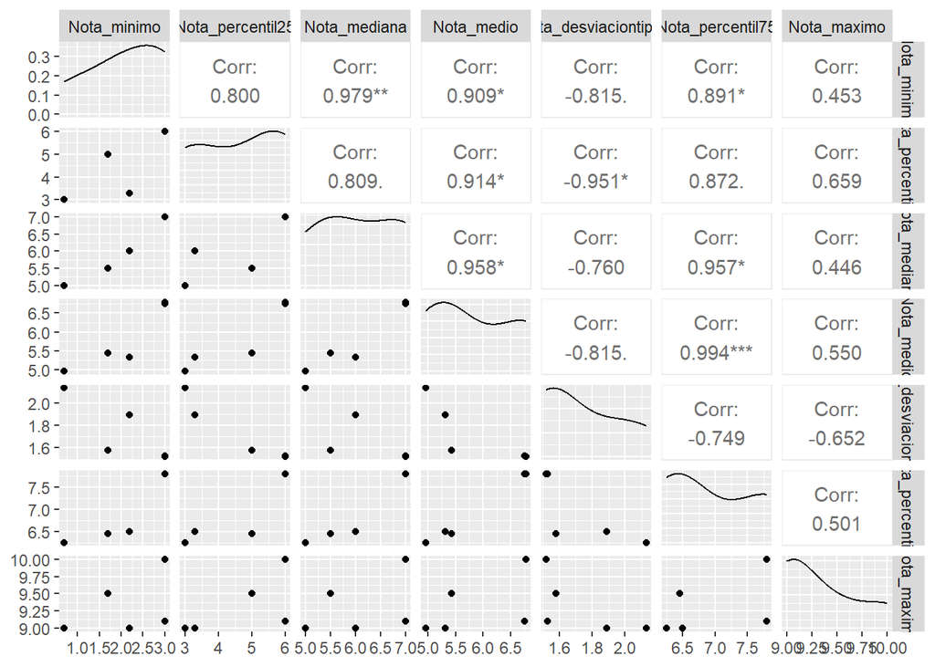

Figure 3.2: Relacion entre todas las variables

```r
# Cargada posteriormente con ggplot2
# library(GGally)
df_estadisticos_notas %>%
  select(-Asignatura) %>%
  ggpairs(.)
```

Podemos ver en la figura 3.2 que hay una relación positiva entre la nota media, mediana y el percentil 75 que obtuvieron los estudiantes de tal curso.

## 3.6 Enunciado

8. Determina las matrices de correlación y covarianza de dichas variables, con las opciones “Spearman” y “Pearson” e indica qué pares de variables tienen la correlación más alta.

```r
# Las estrellas permiten saber si la variable es estadisticamente significativa.

# install.packages("PerformanceAnalytics")
# library(PerformanceAnalytics)
```

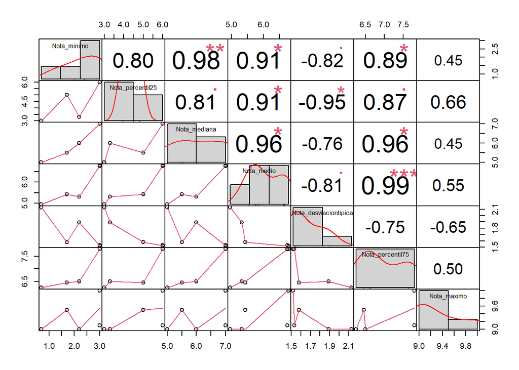

Figure 3.3: Matriz de correlación de Pearson

```r
# # Correlacion
# df_estadisticos_notas %>%
#   select(-Asignatura) %>%
#   cor(., method = 'pearson')

# # Covarianza
# df_estadisticos_notas %>%
#   select(-Asignatura) %>%
#   cov(., method = 'pearson')

df_estadisticos_notas %>%
  select(-Asignatura) %>%
  chart.Correlation(., histogram = TRUE, method = 'pearson')
```

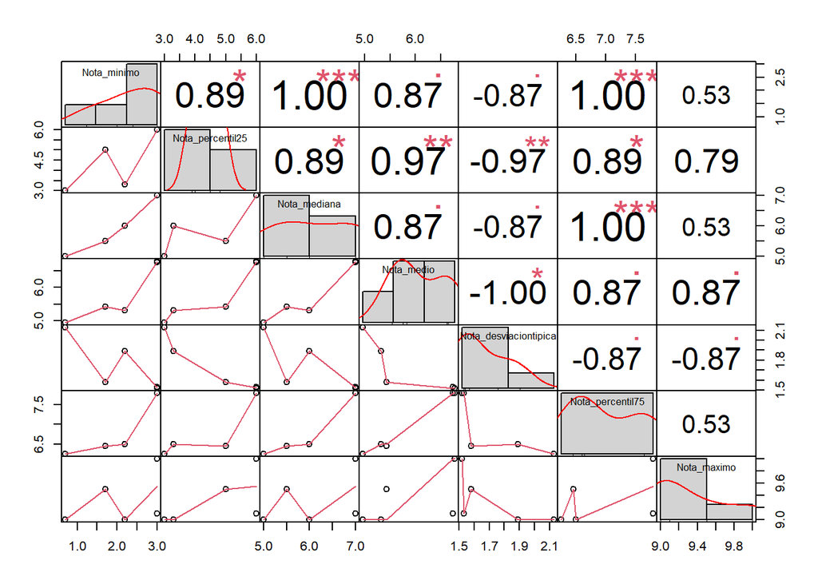

Figure 3.4: Matriz de correlación de Spearman

```r
# # Correlacion
# df_estadisticos_notas %>%
#   select(-Asignatura) %>%
#   cor(., method = 'spearman')

# # Covarianza
# df_estadisticos_notas %>%
#   select(-Asignatura) %>%
#   cov(., method = 'spearman')

df_estadisticos_notas %>%
  select(-Asignatura) %>%
  chart.Correlation(., histogram = TRUE, method = 'spearman')
```

## 3.7 Enunciado

9. Representa en una misma gráfica los boxplots con las calificaciones obtenidas en las diferentes asignaturas.

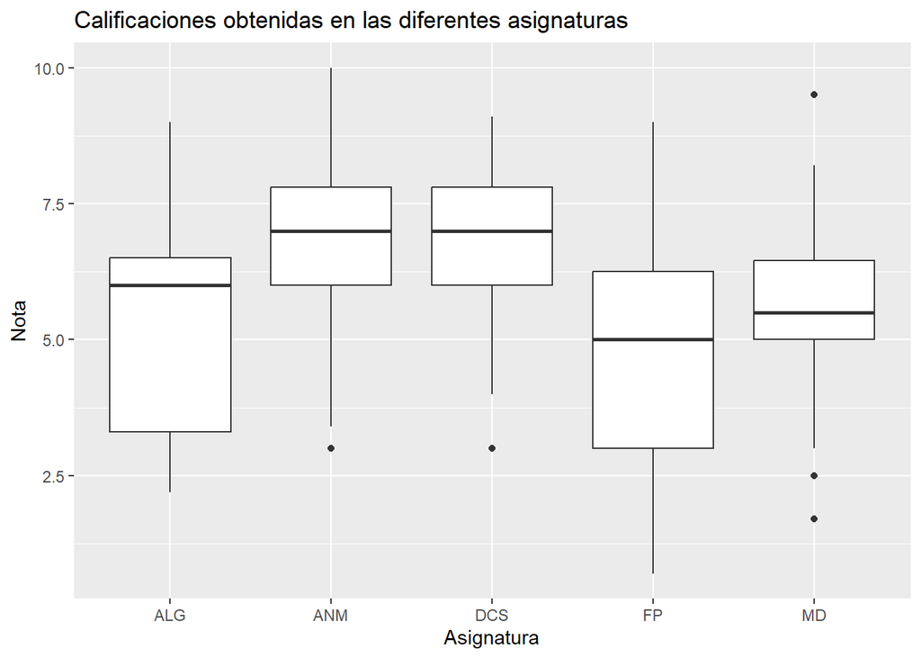

```r
df_notas %>%
  pivot_longer(cols = ALG:MD,
               names_to = 'Asignatura',
               values_to = 'Nota') %>%
  ggplot(aes(x=Asignatura, y=Nota)) +
  geom_boxplot(na.rm=TRUE) +
  labs (title = 'Calificaciones obtenidas en las diferentes asignaturas')
```

## 3.8 Enunciado

10. Añade la variable sexo al conjunto de datos y realiza la representación del boxplot de calificaciones por asignatura coloreando según dicha variable.

Vease la representación en la figura 3.5.

```r
# Corregir los valores de la columna Sex
datos <- datos %>%

        # Quitar los espacios en blanco
            mutate(Sex = str_trim(Sex)) %>%

        # Dejarlas en mayuscula
            mutate(Sex = str_to_upper(Sex))

# Normalizar los valores
datos %>%
  count(Sex)
```

| Sex | n |
| --- | --- |
| F | 17 |
| M | 37 |
| MASCULINO | 4 |

```r
# Guardamos los valores en un vector
inputs <- datos %>%
  distinct(Sex) %>%
  as.vector()
inputs <- inputs[[1]]

# Identificamos los que pueden referirse a M y F
femenino <- inputs[which(str_detect(string = inputs, pattern = 'F'))]
masculino <- inputs[which(str_detect(string = inputs, pattern = 'M'))]

# Actualizamos el dataframe, colapsando los valores
datos <- datos %>%
            mutate(Sex = fct_collapse(Sex, M = masculino)) %>%
            mutate(Sex = fct_collapse(Sex, F = femenino))
```

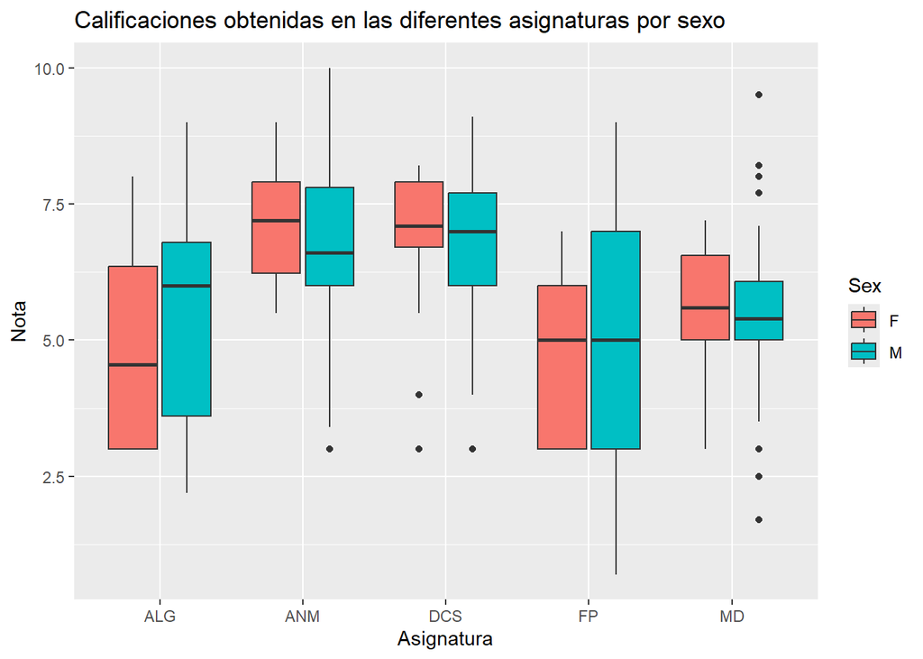

Figure 3.5: Calificaciones por asignatura

```r
datos %>%
  select(Sex, ALG:MD) %>%
  pivot_longer(cols = ALG:MD,
               names_to = 'Asignatura',
               values_to = 'Nota') %>%
  ggplot(aes(x=Asignatura, y=Nota, fill=Sex)) +
  geom_boxplot(na.rm=TRUE) +
  labs (title = 'Calificaciones obtenidas en las diferentes asignaturas por sexo')
```

## 3.9 Enunciado

11. Selecciona los alumnos que tiene calificaciones en todas las asignaturas y represéntalas gráficamente. En el eje X aparecerá el usuario del alumno (girado 90º) y en el eje Y la calificación numérica con un color distinto para cada asignatura. Se mostrará un diagrama de líneas, que una las calificaciones de una misma asignatura para todos los alumnos así como un punto, por asignatura (del mismo color que las líneas), para cada asignatura y alumno.

Vease la figura 3.6.

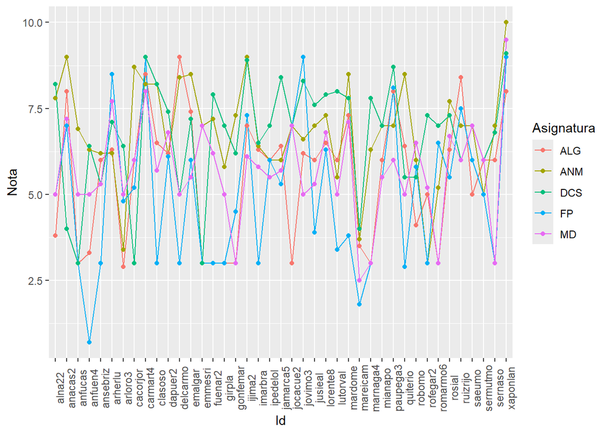

Figure 3.6: Representacion de alumnos con asignaturas completas

```r
# CASOS COMPLETOS
datos %>%
  select(Id, ALG:MD) %>%
  #complete.cases()
  na.omit() %>%

  # CONVERSION A TIDY
  pivot_longer(cols = ALG:MD,
               names_to = 'Asignatura',
               values_to = 'Nota') %>%
  group_by(Id) %>%
  #mutate(Id = factor(Id)) %>%

  # GRAFICO
  ggplot(aes(x=Id, y=Nota, group=Asignatura)) +
  geom_line(aes(color = Asignatura)) +
  #geom_line(aes(linetype = Asignatura, color = Asignatura)) +
  geom_point(aes(color = Asignatura)) +
  theme(axis.text.x = element_text(angle = 90))
```

## 3.10 Enunciado

12. Sin hacer ninguna modificación en el código utiliza el fichero correspondiente al año 2025 y compara los resultados con los del curso 2022

No se han obtenido los mismos resultados. Habían valores/errores que no estaban considerados en el fichero 2022.

- Cantidad de estudiantes
- Valores faltantes
- Control sobre los valores de entrada (M, M , Masculino)

A pesar de que los valores son notablemente diferentes, se puede apreciar la correlacion entre la mediana y el percentil 75.

## 3.11 Preguntas a partir del enunciado 13

13. Responde a las siguientes preguntas, utilizando los datos del curso 2025. Ten en cuenta que deberás hacer correcciones en los datos en aquellos casos en los que los valores introducidos contengan errores. Por ejemplo si en las instrucción se indica que para el sexo de nacimiento los valores posibles son M y F, cualquier otro valor deberá ser corregido. Si la corrección no es posible sustituye por NA. Debes justificar todas las cuestiones con los datos disponibles.

$\textbf{Nota: Se han hecho los respectivos cambios para continuar con los siguientes apartados.}$

### 3.11.1 Enunciado

1. ¿Qué edad, expresada en años (con decimales) tiene el alumno más joven a fecha 01/02/2025.

En principio, el formato de fecha debe ser dd-mm-yyy. Sin embargo, sabemos que se pueden presentar otros formatos, debido al error humano.

```r
# EXPRESION REGULAR PARA VER LOS FORMATOS DE FECHA
# ^ inicio de la cadena
# \\d <- Será un digito
# \\d{n} <- n digitos
# $ fin de la cadena

# Quitar los espacios en blanco en la columna
datos <- datos %>%
            mutate(Fecha = str_trim(Fecha))

datos %>%
  # Ver que fechas siguen el patron '^\\d{2}-\\d{2}-\\d{4}$' (dd-mm-yyyy)
  filter(!if_any(.cols = everything(),
                .fns = ~ str_detect(string = ., pattern = '^\\d{2}-\\d{2}-\\d{4}$')))

  # Hay 8 registros con formato dd-m-yyyy o dd/mm/yyyy
```

Vamos a separar la columna fecha, para obtener los valores individuales de dia, mes y año, y luego los uniremos nuevamente en un formato estandarizado para convertir a la columna fecha en su formato correcto.

```r
datos <- datos %>%
            # Separamos las columnas
            separate(col = Fecha, into = c('dia', 'mes', 'anio'), sep = '[/-]') %>%

            # Convertimos a enteros para comprobar que los valores no estén fuera de rango
            mutate(across(.cols = dia:anio,
                          .fns = ~ as.integer(.)))
```

```r
# Comprobamos
datos %>%
  select(dia:anio) %>%
  filter(dia > 31 | mes > 12 | anio > 2010)
  # De haber datos que cumplan esto, habría que tratarlos
```

```r
# Unir los datos para convertir a fecha en el formato adecuado
datos <- datos %>%
            mutate(across(.cols = dia:anio,
                          .fns = ~ as.character(.))) %>%
            unite(col = Fecha, c(dia:anio), sep = '-') %>%
            # Para formato dd-mm-yyyy
            mutate(Fecha = as.Date(Fecha, format = '%d-%m-%Y'))
```

Ahora hacemos las operaciones correspondientes para la edad del alumno más joven a fecha 01/02/2025.

```r
# Asignamos la fecha para comparar
fecha <- '01/02/2025'
fecha_filtro <- as.Date(fecha, format = '%d/%m/%Y') # Formato en que se recibe
fecha_filtro <- as.Date(fecha_filtro, format = '%d-%m-%Y') # Formato en que se compara

# Operamos
t <- datos %>%
  select(Fecha, Id) %>%
  # interval(fechainicio, fechafin), days(1), weeks(1), months(1)...
  mutate(Edad = round(interval(Fecha, fecha_filtro) / years(1), 2)) %>%
  arrange(Edad) %>%
  head(., 1)

kable(t, caption = 'Estudiante mas joven', booktabs = FALSE)
```

Table 3.4: Estudiante mas joven

| Fecha | Id | Edad |
| --- | --- | --- |
| 2006-12-31 | delcarmo | 18.09 |

En la tabla 3.4 podemos apreciar que el estudiante más joven a la fecha es ‘delcarmo’.

### 3.11.2 Enunciado

2. Cuántos alumnos simultánean trabajo y estudios.

Para comprobar esto, haremos uso de la variable ‘Hwork’. A priori, los registros son de estudiantes. Por lo tanto, lo unico que nos interesa saber, es si trabaja (Hwor > 0), o no.

```r
datos %>%
  mutate(Hwork = as.integer(Hwork)) %>%
  count(Hwork) # Vemos los diferentes valores que hay para Hwork
```

```r
datos <- datos %>%
  mutate(Hwork = as.integer(Hwork)) %>%
  # Se debe pasar una lista = list(columna = valor)
  replace_na(list(Hwork = 0))

EyT <- datos %>%
  count(Hwork) %>%
  filter(Hwork != 0) %>%
  summarise('Total' = sum(n))

kable(EyT,
      caption = 'Estudiantes que trabajan y estudian',
      booktabs = FALSE)
```

Table 3.5: Estudiantes que trabajan y estudian

| Total |
| --- |
| 15 |

### 3.11.3 Enunciado

3. Hay más hombres o más mujeres fumadoras.

```r
datos %>%
  count(Smoke) # Vemos los valores que recibe la variable Smoke, ya que Sex está normalizado
```

```r
# Estandarizamos la variable
datos <- datos %>%
            mutate(Smoke = str_trim(Smoke)) %>% # Eliminar espacios
            mutate(Smoke = str_to_lower(Smoke)) # Dejar todo en minuscula

datos %>% count(Smoke) # Valores recibidos no, si, de fiesta
```

| Smoke | n |
| --- | --- |
| de fiesta | 1 |
| no | 50 |
| si | 7 |

```r
datos <- datos %>%
            mutate(Smoke = ifelse(Smoke != 'no', 'si', Smoke))
```

Una vez que ya se ha normalizado, contamos.

```r
fuman <- datos %>%
  select(Sex, Smoke) %>%
  # Como queremos saber los que fuman, ya sean hombres o mujeres
  filter(Smoke == 'si') %>%

  # Agrupamos por sexo y contamos
  group_by(Sex) %>%
  count(name = 'Fuman')

kable(fuman,
      caption = 'Total de hombres y mujeres fumadoras',
      booktabs = FALSE)
```

Table 3.6: Total de hombres y mujeres fumadoras

| Sex | Fuman |
| --- | --- |
| F | 2 |
| M | 6 |

En la tabla En la tabla 3.6, vemos que hay más hombres que fuman.

### 3.11.4 Enunciado

4. Cuál es el valor medio y la varianza de la variable Wr.Hnd según el sexo.

```r
# Verificamos los valores
datos %>%
  filter(is.na(Wr.Hnd))
```

```r
datos %>%
  mutate(Wr.Hnd = as.double(Wr.Hnd)) %>% # Esto nos presenta un error por la presencia de coma
  filter(is.na(Wr.Hnd))
```

```r
# Hacemos la conversion de dato
datos <- datos %>%
  mutate(across(.col = Wr.Hnd,
                .fns = ~ str_replace_all(., ',', '.'))) %>%
  mutate(Wr.Hnd = as.numeric(Wr.Hnd))
```

```r
datos %>%
  select(Sex, Wr.Hnd) %>%
  group_by(Sex) %>%
  summarise(Valor_medio = mean(Wr.Hnd),
            Varianza = var(Wr.Hnd))
```

| Sex | Valor_medio | Varianza |
| --- | --- | --- |
| F | 16.67647 | 11.779412 |
| M | 19.12195 | 7.759756 |

### 3.11.5 Enunciado

5. Determina si existe relación entre el sexo y la mano con la que se escribe (NW.Hnd)

```r
# Vemos los valores que recibe la variable
datos %>%
  distinct(NW.Hnd)
```

```r
# Limpieza de la columna NW.Hnd
datos <- datos %>%
            mutate(NW.Hnd = str_trim(NW.Hnd)) %>% # Eliminar los espacios
            mutate(NW.Hnd = str_to_upper(NW.Hnd)) # Dejar todo en mayuscula

# Verificamos valores
datos %>%
  distinct(NW.Hnd) # Vemos que aún hay un error
```

| NW.Hnd |
| --- |
| DERCHA |
| DERECHA |
| IZQUIERDA |

```r
# Valores a corregir
escribe <- datos %>%
              distinct(NW.Hnd) %>% # Valores que recibe la columna
              as.vector()
escribe <- escribe[[1]]
```

```r
Esc_Der <- escribe[which(str_detect(string = escribe, pattern = '^D'))]
Esc_Izq <- escribe[which(str_detect(string = escribe, pattern = '^I'))]

# Corregimos los valores en el dataframe original
datos <- datos %>%
            mutate(NW.Hnd = fct_collapse(NW.Hnd, D = Esc_Der)) %>%
            mutate(NW.Hnd = fct_collapse(NW.Hnd, I = Esc_Izq))
```

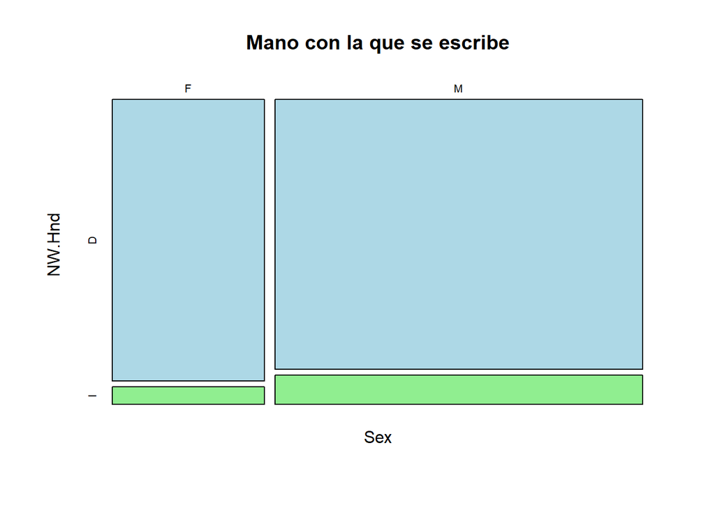

```r
t_mano <- datos %>%
            select(Sex, NW.Hnd) %>%
            mutate(Sex = as.character(Sex), NW.Hnd = as.character(NW.Hnd)) %>%
            table()
t_mano %>% plot(col = c('lightblue', 'lightgreen'), main = 'Mano con la que se escribe')
```

Hacemos la comprobacion con el chi-cuadrado. Es importante saber que partimos desde Ho, que es una hipotesis, de que los datos son independientes. Por lo tanto:

```r
# p<0.05 —> Rechazamos hipótesis = No son independientes
# p>=0.05 —> Aceptamos Ho = Son independientes y por tanto, no hay relación entre los datos
chi2 <- chisq.test(t_mano, correct = F) # Valores muy pequeños. Resultados pueden ser incorrectos
```

Dado que los valores son pequeños para la mano izquierda, vamos a comprobar solo con la mano Derecha.

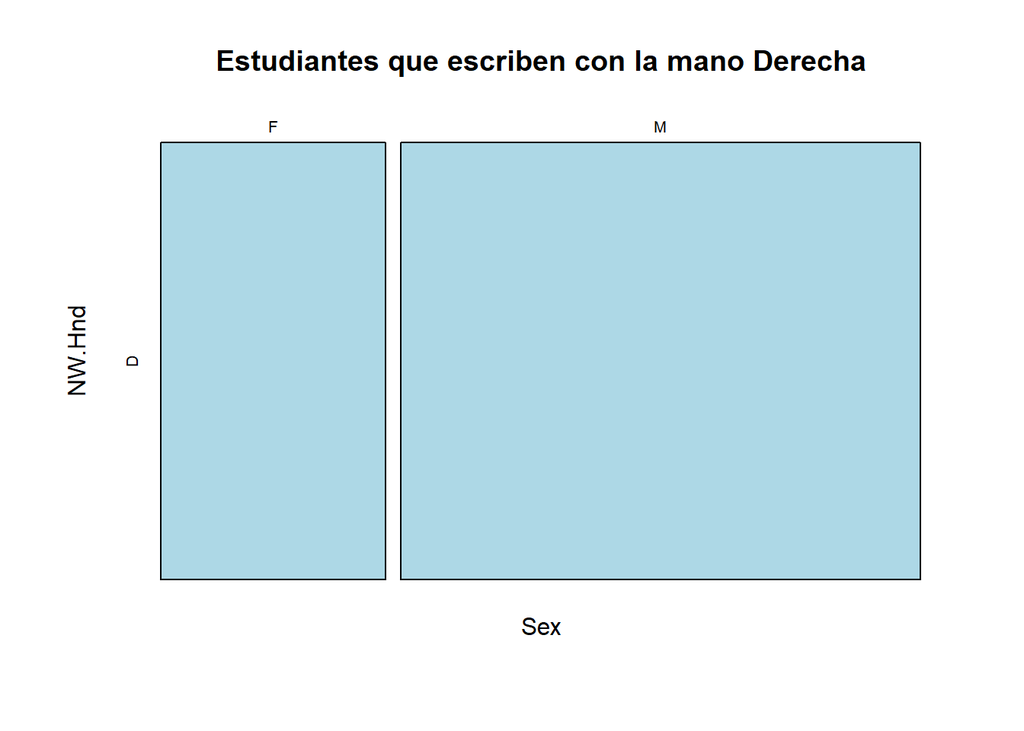

```r
t_mano_d <- datos %>%
            select(Sex, NW.Hnd) %>%
            mutate(Sex = as.character(Sex), NW.Hnd = as.character(NW.Hnd)) %>%
            filter(NW.Hnd == 'D') %>%
            table()
t_mano_d %>% plot(col = 'lightblue', main = 'Estudiantes que escriben con la mano Derecha')
```

```r
# p<0.05 —> Rechazamos hipótesis = No son independientes
# p>=0.05 —> Aceptamos Ho = Son independientes y por tanto, no hay relación entre los datos
chi2 <- chisq.test(t_mano_d, correct = F) # Valores muy pequeños. Resultados pueden ser incorrectos
chi2
```

```
##
##  Chi-squared test for given probabilities
##
## data:  t_mano_d
## X-squared = 8.3208, df = 1, p-value = 0.003919
```

Evaluando solo la mano derecha, podríamos decir que si hay una asociacion entre el sexo y escribir con la mano derecha. Sin embargo, dado la proporción de mujeres y hombres en el aula, no es posible asumirlo correctamente.

### 3.11.6 Enunciado

6. Existe una relación lineal entre la altura (Height) y la distancia del extremo del meñique al extremo del pulgar de la mano con la que escribimos (Wr.Hnd)

```r
# Verificamos los datos de la columna Height
datos %>%
  filter(is.na(Height)) # No tenemos valores nulos
```

```r
# Hacemos la conversión a entero
datos %>%
  mutate(Height = as.integer(Height)) # Hay error por la coma
```

```r
# Corregimos el dato
datos <- datos %>%
            mutate(across(.col = Height,
                          .fns = ~ str_replace_all(., ',', '.'))) %>%
            mutate(Height = as.numeric(Height))
```

```r
# Verificamos datos
# Dado que conocemos el grupo, ningun alumno mide menos de 1 metro = 100 cm, y ninguno mide mas de 2 metros = 200 cm
datos %>%
  filter(Height < 100 | Height > 200)
```

```r
# Corregimos el dato, usando el filtro anterior.
datos <- datos %>%
            mutate(Height = ifelse(Height < 100, Height * 100, Height))
```

Una vez que tenemos limpio el df, procedemos.

```r
head(datos)
```

| Fecha | Id | Age | Sex | Wr.Hnd | NW.Hnd | Fold | Pulse | Clap | Exer | Smoke | Height | ALG | ANM | FP | DCS | MD | HSt | Hwork | Comentarios |
| --- | --- | --- | --- | --- | --- | --- | --- | --- | --- | --- | --- | --- | --- | --- | --- | --- | --- | --- | --- |
| 2006-02-22 | olrae | 18 | M | 20 | D | izquierdo | 60 | Der s Izq | 12 | no | 173 | 7.2 | 6.2 | NA | 4.0 | 1.7 | 1,5 | 5 | Esta asignatura es la mejor de todas me encanta el almacenamiento de los datos y como se comportan |
| 2006-11-07 | jusieal | 18 | M | 20 | D | Izquierdo | 62 | Der s Izq | 1 | si | 180 | 6.0 | 7.0 | 3.9 | 7.6 | 5.3 | 1 | 0 | Asignatura práctica y amena |
| 2004-01-28 | jovimo3 | 21 | M | 18 | D | Izquierdo | 65 | Der s Izq | 3 | no | 173 | 6.2 | 6.6 | 9.0 | 8.3 | 5.0 | 3 | 0 | Esta asignatura es mejor que la de bases de datos |
| 2003-10-11 | carmart4 | 21 | M | 20 | D | Izquierdo | 69 | Der s Izq | 3 | no | 172 | 8.5 | 8.2 | 9.0 | 9.0 | 8.0 | 6 | 25 | El control de versiones es fundamental para los trabajos de entrenamiento de modelos de aprendizaje |
| 2006-07-20 | anfuen4 | 18 | M | 21 | D | Derecho | 65 | Der s Izq | 8 | si | 179 | 3.3 | 6.3 | 0.7 | 6.4 | 5.0 | 2 | 12 |  |
| 2005-11-11 | eansan2 | 19 | M | 16 | D | Derecha | 92 | Der s Izq | si | no | 185 | 6.8 | 7.8 | 2.8 | NA | 6.3 | 0 | 0 | Igual que el de abajo |